# Machine Learning Personal Activity Prediction

Rajeev Kumar

March 22, 2017

## Overview

The aim of this work is to predict how well an individual performed exercise.

Six participants were asked to perform barbell lifts correctly and incorrectly in 5 different ways.By using data from accelerometers on the belt, forearm, arm, and dumbell we aim to predict which class the observation falls in. “classe” variable in the training set describes manner in which an individual performed exercise.

The machine learning algorithm described here is applied to the 20 test cases available in the test data.

## Machine Learning Prediction

### Load Input Data

```r
urlTrain<-"https://d396qusza40orc.cloudfront.net/predmachlearn/pml-training.csv"

urlTest<-"https://d396qusza40orc.cloudfront.net/predmachlearn/pml-testing.csv"

# Read input training data
pmTrain <-read.csv(urlTrain,na.strings=c("NA", "#DIV/0!",""))

# Read input test data
pmTest <-read.csv(urlTest,na.strings=c("NA","#DIV/0!",""))
```

### Input Data Pre-Processing

1. Find Structure of pmTrain data set

```r
dim(pmTrain)
```

```
## [1] 19622   160
```

```r
## count no of NA for each column in dataframe pmTrain

x1<-apply(pmTrain,2,function (x){sum(is.na(x))})
```

We observed that majority of columns in dataframe pmTrain with non-zero NA has total count of NA in such columns more than 19000

2. subset columns in input dataframe pmTrain where total count of NA in given column >19000 is false

```r
x1<-pmTrain[,-which(as.numeric(colSums(is.na(pmTrain)))>19000)]
dim(x1)
```

```
## [1] 19622    60
```

3. Some variables are irrelevant to our current project: user_name, raw_timestamp_part_1, raw_timestamp_part_,2 cvtd_timestamp, new_window, and num_window (columns 1 to 7). We can delete these variables

```r
x1<-x1[,-c(1:7)]
dim(x1)
```

```
## [1] 19622    53
```

4. Load Caret package and rattle package

```r
library(caret)
library(rattle)
```

### Create Data Partision into training and test data set

```r
# Create Data Partision into training and testing for input pre-prcessed dataset x1

intrain<-createDataPartition(x1$classe,p=0.7,list=FALSE)

training<-x1[intrain,]
testing<-x1[-intrain,]

dim (training)
```

```
## [1] 13737    53
```

```r
dim (testing)
```

```
## [1] 5885   53
```

### Model Building and Analysis

1. Model building and Analyisis using Decision Tree with default value of train function

```r
# Model building using rpart with default values of train function in CARET package
set.seed (100)
modFit1<-train (classe ~.,data=training,method="rpart")
print(modFit1$finalModel)
```

```
## n= 13737
##
## node), split, n, loss, yval, (yprob)
##       * denotes terminal node
##
##  1) root 13737 9831 A (0.28 0.19 0.17 0.16 0.18)
##    2) roll_belt< 130.5 12573 8677 A (0.31 0.21 0.19 0.18 0.11)
##      4) pitch_forearm< -33.95 1101    8 A (0.99 0.0073 0 0 0) *
##      5) pitch_forearm>=-33.95 11472 8669 A (0.24 0.23 0.21 0.2 0.12)
##       10) magnet_dumbbell_y< 439.5 9678 6935 A (0.28 0.18 0.24 0.19 0.11)
##         20) roll_forearm< 123.5 6061 3603 A (0.41 0.18 0.18 0.17 0.063) *
##         21) roll_forearm>=123.5 3617 2395 C (0.079 0.18 0.34 0.23 0.18) *
##       11) magnet_dumbbell_y>=439.5 1794  883 B (0.033 0.51 0.039 0.23 0.19) *
##    3) roll_belt>=130.5 1164   10 E (0.0086 0 0 0 0.99) *
```

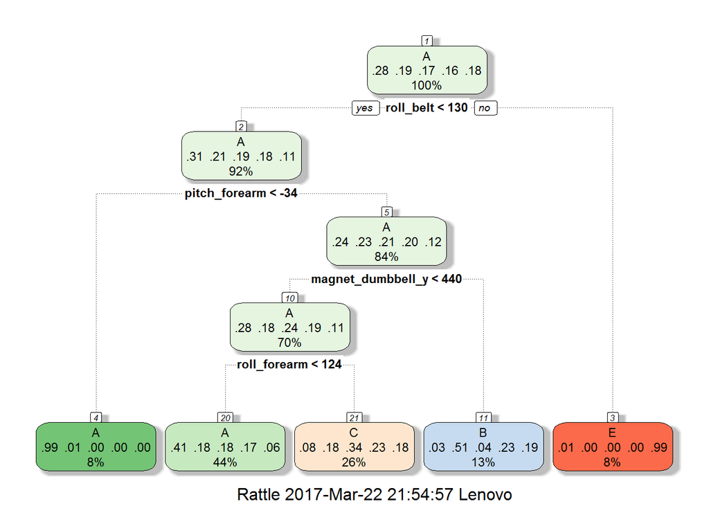

```r
fancyRpartPlot(modFit1$finalModel)
```

```r
# Predictions on testing data set
predictions1 <- predict(modFit1, newdata=testing)
confusionMatrix(predictions1, testing$classe)
```

```
## Confusion Matrix and Statistics
##
##           Reference
## Prediction    A    B    C    D    E
##          A 1529  472  483  435  140
##          B   21  375   38  151  150
##          C  120  292  505  378  315
##          D    0    0    0    0    0
##          E    4    0    0    0  477
##
## Overall Statistics
##
##                Accuracy : 0.4904
##                  95% CI : (0.4775, 0.5033)
##     No Information Rate : 0.2845
##     P-Value [Acc > NIR] : < 2.2e-16
##
##                   Kappa : 0.3341
##  Mcnemar's Test P-Value : NA
##
## Statistics by Class:
##
##                      Class: A Class: B Class: C Class: D Class: E
## Sensitivity            0.9134  0.32924  0.49220   0.0000  0.44085
## Specificity            0.6367  0.92415  0.77259   1.0000  0.99917
## Pos Pred Value         0.4998  0.51020  0.31366      NaN  0.99168
## Neg Pred Value         0.9487  0.85165  0.87813   0.8362  0.88805
## Prevalence             0.2845  0.19354  0.17434   0.1638  0.18386
## Detection Rate         0.2598  0.06372  0.08581   0.0000  0.08105
## Detection Prevalence   0.5198  0.12489  0.27358   0.0000  0.08173
## Balanced Accuracy      0.7750  0.62669  0.63239   0.5000  0.72001
```

Overall accuracy of model is low hence let us run model by scaling and cross validations.

2. Model building and Analyisis using Decision Tree with scaling and cross validation

```r
# Model building using rpart with scaling and cross validation
set.seed (100)

modFit1 <- train(classe ~ .,  preProcess=c("center", "scale"), trControl=trainControl(method = "cv", number = 4), data = training, method="rpart")
print(modFit1$finalModel)
```

```
## n= 13737
##
## node), split, n, loss, yval, (yprob)
##       * denotes terminal node
##
##  1) root 13737 9831 A (0.28 0.19 0.17 0.16 0.18)
##    2) roll_belt< 1.050896 12573 8677 A (0.31 0.21 0.19 0.18 0.11)
##      4) pitch_forearm< -1.584495 1101    8 A (0.99 0.0073 0 0 0) *
##      5) pitch_forearm>=-1.584495 11472 8669 A (0.24 0.23 0.21 0.2 0.12)
##       10) magnet_dumbbell_y< 0.6640623 9678 6935 A (0.28 0.18 0.24 0.19 0.11)
##         20) roll_forearm< 0.8383375 6061 3603 A (0.41 0.18 0.18 0.17 0.063) *
##         21) roll_forearm>=0.8383375 3617 2395 C (0.079 0.18 0.34 0.23 0.18) *
##       11) magnet_dumbbell_y>=0.6640623 1794  883 B (0.033 0.51 0.039 0.23 0.19) *
##    3) roll_belt>=1.050896 1164   10 E (0.0086 0 0 0 0.99) *
```

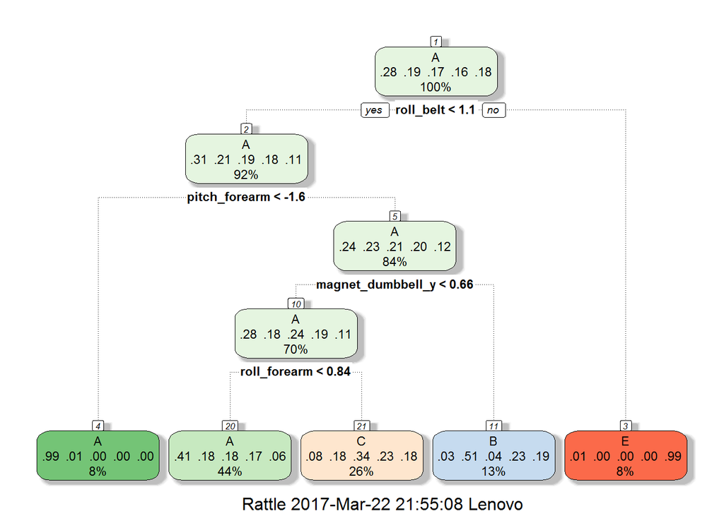

```r
fancyRpartPlot(modFit1$finalModel)
```

```r
# Predictions on testing data set
predictions1 <- predict(modFit1, newdata=testing)
confusionMatrix(predictions1, testing$classe)
```

```
## Confusion Matrix and Statistics
##
##           Reference
## Prediction    A    B    C    D    E
##          A 1529  472  483  435  140
##          B   21  375   38  151  150
##          C  120  292  505  378  315
##          D    0    0    0    0    0
##          E    4    0    0    0  477
##
## Overall Statistics
##
##                Accuracy : 0.4904
##                  95% CI : (0.4775, 0.5033)
##     No Information Rate : 0.2845
##     P-Value [Acc > NIR] : < 2.2e-16
##
##                   Kappa : 0.3341
##  Mcnemar's Test P-Value : NA
##
## Statistics by Class:
##
##                      Class: A Class: B Class: C Class: D Class: E
## Sensitivity            0.9134  0.32924  0.49220   0.0000  0.44085
## Specificity            0.6367  0.92415  0.77259   1.0000  0.99917
## Pos Pred Value         0.4998  0.51020  0.31366      NaN  0.99168
## Neg Pred Value         0.9487  0.85165  0.87813   0.8362  0.88805
## Prevalence             0.2845  0.19354  0.17434   0.1638  0.18386
## Detection Rate         0.2598  0.06372  0.08581   0.0000  0.08105
## Detection Prevalence   0.5198  0.12489  0.27358   0.0000  0.08173
## Balanced Accuracy      0.7750  0.62669  0.63239   0.5000  0.72001
```

There is no imporvement in overall accurach hence let us predict using Generalized Boosted Model.

3. Model building and Analyisis using Generalized Boosted Model

```r
# Model building using Generalized Boosted Model
set.seed (100)

controlGBM <- trainControl(method = "repeatedcv", number = 5, repeats = 1)

modFitGBM <-train(classe ~ ., data=training, method = "gbm",trControl = controlGBM, verbose = FALSE)
print(modFitGBM$finalModel)
```

```
## A gradient boosted model with multinomial loss function.
## 150 iterations were performed.
## There were 52 predictors of which 44 had non-zero influence.
```

```r
# Predictions on testing data set
predictions2 <- predict(modFitGBM, newdata=testing)
confusionMatrix(predictions2, testing$classe)
```

```
## Confusion Matrix and Statistics
##
##           Reference
## Prediction    A    B    C    D    E
##          A 1649   41    0    2    0
##          B   17 1052   29    4    7
##          C    7   46  986   32    7
##          D    1    0    8  917   18
##          E    0    0    3    9 1050
##
## Overall Statistics
##
##                Accuracy : 0.9607
##                  95% CI : (0.9555, 0.9656)
##     No Information Rate : 0.2845
##     P-Value [Acc > NIR] : < 2.2e-16
##
##                   Kappa : 0.9503
##  Mcnemar's Test P-Value : NA
##
## Statistics by Class:
##
##                      Class: A Class: B Class: C Class: D Class: E
## Sensitivity            0.9851   0.9236   0.9610   0.9512   0.9704
## Specificity            0.9898   0.9880   0.9811   0.9945   0.9975
## Pos Pred Value         0.9746   0.9486   0.9147   0.9714   0.9887
## Neg Pred Value         0.9940   0.9818   0.9917   0.9905   0.9934
## Prevalence             0.2845   0.1935   0.1743   0.1638   0.1839
## Detection Rate         0.2802   0.1788   0.1675   0.1558   0.1784
## Detection Prevalence   0.2875   0.1884   0.1832   0.1604   0.1805
## Balanced Accuracy      0.9874   0.9558   0.9710   0.9729   0.9840
```

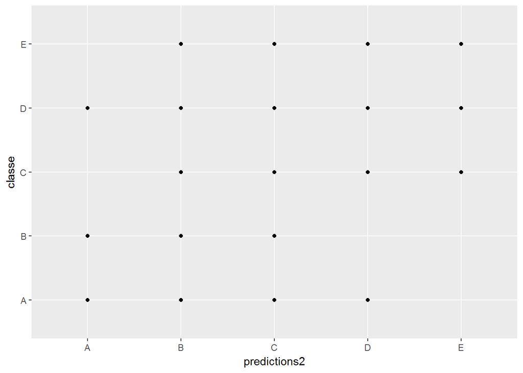

```r
qplot (predictions2,classe,data=testing)
```

### Applying best model on input testing data set pmTest

Since Generalized Boosted Model has best accuracy among 3 model, it is chosen as best model to predict value for input test data set -pmTest.

```r
# Apply best model - Generalized Boosted Model on input testing data set pmTest
set.seed (200)

# Predictions
predictionsInputTest <- predict(modFitGBM, newdata=pmTest)
predictionsInputTest
```

```
##  [1] B A B A A E D B A A B C B A E E A B B B
## Levels: A B C D E
```